# Caculate MLE

Kim Youngrae

2016년 10월 31일

# Content

- Algorithm
- Result

# Algorithm

MLE를 계산하는 알고리즘을 먼저 생각해보면 다음과 같다.

- Initialize $\Psi^{(0)}$. for k = 1,2,…
- Calculate $L^{(k)}$ by (6) with $\Psi^{(k-1)}$.
- Calculate $\Psi^{(k)}$ by (9) with $L^{(k)}$.
- Stop when it converges

강의록의 식 (6)은 식 (10)과 동치이며, 이는 $\Psi^{-1/2}S_n\Psi^{-1/2}$를 Eigen decomposition해서 구할 수 있음을 알 수 있다. (교재 p528-529의 내용)

$L(L^T\Psi^{-1}L+I_m)=S_n\Psi^{-1}L - (6)$ $diag(LL^T+\Psi)=diag(S_n) - (9)$ $(\Psi^{-1/2}S_n\Psi^{-1/2})(\Psi^{-1/2}L) = (\Psi^{-1/2}L)(I_m+ L^T\Psi^{-1}L) - (10)$

(강의록의 식 (10)에 오타가 있습니다. 이게 맞는것 같습니다.)

식 (10)을 이용해서 L을 계산하는 방법을 조금 더 자세히 알아보면 주어진 $\hat{\Psi}$에 대해서, “uniqueness-rescaled” covariance $S^*=\hat{\Psi}^{-1/2}S_n\hat{\Psi}^{-1/2}$을 구한다.

이것의 Eigenvalue를 $\hat{\Lambda}$, (Normalized) Eigenvector로 만든 행렬을 $\hat{E}$라 하면 다음과 같은 식이 성립한다. $\hat{\Lambda} = I+\hat{\Delta}, \hspace{5mm} \hat{E}=\hat{\Psi}^{-1/2}\hat{L}\hat{\Delta}^{-1/2}$

식 (10)을 잘 살펴보면, $\Psi^{-1/2}L$의 $j$번째 열이, $I_m+ L^T\Psi^{-1}L$의 $j$번째 값을 eigenvalue 로 갖는 (non-normalized) eigenvector의 모양임을 알 수 있다.

($I_m+ L^T\Psi^{-1}L$는 diagonal이므로, 하나씩 비교해보면 된다. $Av=\lambda v$의 모양으로 만들 수 있음.)

이제, 식 10의 $\Psi$가 모두 추정된 $\hat{\Psi}$라고 생각하고, 대입해서 생각해보면, 행렬의 Eigenvalue는 당연히 같아져야 하므로,

$I_m+L^T\hat{\Psi}^{-1}L = \hat{\Lambda}, \hspace{5mm} where \hspace{3mm} L^T\hat{\Psi}^{-1}L= \hat{\Delta}$

이고,

$L^T\hat{\Psi}^{-1}L= \hat{\Delta}$

에 의해, Normalized eigenvector는

$\hat{E}=\hat{\Psi}^{-1/2}\hat{L}\hat{\Delta}^{-1/2}$

로 구할 수 있다.

이제 다시 MLE를 구하는 Algorithm으로 돌아가 생각해보면, 우리는 $\hat{\Psi}$를 알고 있는 상황에서, $\hat{L}$을 먼저 구해야하므로, 마지막 식

$\hat{E}=\hat{\Psi}^{-1/2}\hat{L}\hat{\Delta}^{-1/2}$

# Result

자료를 입력한다. 실습시간에 했던 것처럼 교재 Table 8-5의 자료를 사용했다.

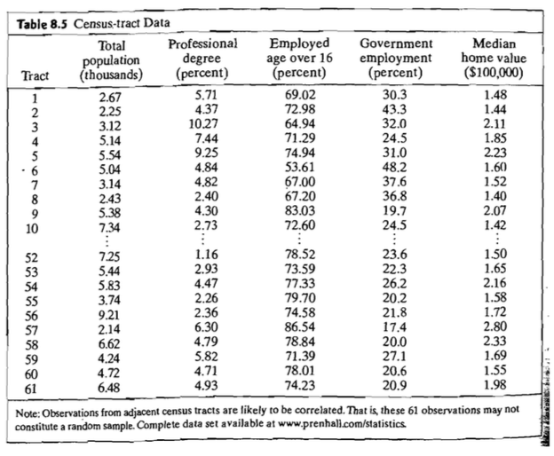

```r
data <-read.table("/Users/kyr0302/Desktop/Lab_4/T8-5.dat",header=FALSE,sep="");
n=nrow(data);p=ncol(data);
cov=cov(data); ## sample covariance
```

여기서 cov 함수로 구한 공분산은 Sample covariance인데, 이는 분산의 MLE와 다르다. $S_{sample}=\frac{1}{n-1}\sum_{k=1}^n(X_k-\bar{X})(X_k-\bar{X})^t \hspace{5mm} S_{MLE}=\frac{1}{n}\sum_{k=1}^n(X_k-\bar{X})(X_k-\bar{X})^t$

따라서 우리의 MLE 계산식에 있는 $S_n$은, 항상 $\frac{n-1}{n}$를 곱하여 생각해주어야 한다.

계산하기 위해서, 먼저 Initial $\Psi$를 정한다. 여기서는 교재의 528p의 (9A-4) 에 나온 것을 생각하였다.

$\hat{\psi}_i=(1-\frac{1}{2}\dot\frac{m}{p})(\frac{1}{s^{ii}})$.

여기서 $s^{ii}$ 는 $S^{-1}$의 $i$번째 대각원소이다.

Factor의 개수는 2개로 하고 분석하도록 한다. (m은 조정할 수 있다.)

```r
m=2;
psi <- (1-m/(2*p))*diag(1/diag(solve(cov)))

tol=10^(-5)             # For iteration
psi.old=diag(rep(0,5))  # For iteration
iter.num=1              # For iteration
```

이제 반복부분을 만들면,

```r
while(norm(as.matrix(psi-psi.old),type="F")>tol){
  psi.old<-psi;
  S.star<-sqrt(solve(psi.old))%*%cov%*%sqrt(solve(psi.old))*(n-1)/n   ## Uniqueness-rescaled covariance
  eig.res<-eigen(S.star);                                             ## Eigen decomposition
  E<-eig.res$vectors[,1:m]; Delta<-diag(eig.res$values[1:m]-1);       ## Ehat, Deltahat
  L<-sqrt(psi.old)%*%E%*%sqrt(Delta)                                  ## Calculate L
  psi<-diag(diag(cov*(n-1)/n-L%*%t(L)))                               ## Calculate Psi
  for(i in 1:p){
    if(diag(psi)[i]<0){
      diag(psi)[i]=0.005
    }                                                                 ## For Haywood case
  }
  iter.num<-iter.num+1
  # cat("iter.num=",iter.num,"psi=",psi[1,1],psi[2,2],psi[3,3],psi[4,4],psi[5,5],"\n")
  # Psi가 반복하면서 어떻게 변하는지 보고싶을 때 사용.
}
```

위와 같이 Coding할 수 있고, 이렇게 구해진 $L$과 $\Psi$는 다음과 같다.

```r
L
```

```
##            [,1]        [,2]
## [1,]  0.3551013 -0.54916529
## [2,] -3.0839466 -0.02084755
## [3,]  0.5324263 -7.36498193
## [4,] -3.5175858  3.60971472
## [5,] -0.3835501 -0.02207496
```

```r
psi
```

```
##          [,1]        [,2]      [,3]     [,4]      [,5]
## [1,] 2.913533 0.000000000 0.0000000  0.00000 0.0000000
## [2,] 0.000000 0.003043393 0.0000000  0.00000 0.0000000
## [3,] 0.000000 0.000000000 0.1875749  0.00000 0.0000000
## [4,] 0.000000 0.000000000 0.0000000 62.20305 0.0000000
## [5,] 0.000000 0.000000000 0.0000000  0.00000 0.1658037
```

$S_n$과 $LL^T+\Psi$를 비교해보면,

```r
cov*(n-1)/n-(L%*%t(L)+psi)
```

```
##               V1            V2            V3            V4            V5
## V1  0.0000000000 -4.069282e-04  1.314263e-03  1.1872142172  1.508343e-01
## V2 -0.0004069282  0.000000e+00  3.168041e-06  0.0008780664  3.303969e-05
## V3  0.0013142629  3.168041e-06  0.000000e+00 -0.0047408520 -1.214502e-03
## V4  1.1872142172  8.780664e-04 -4.740852e-03  0.0000000000 -3.278798e-01
## V5  0.1508342708  3.303969e-05 -1.214502e-03 -0.3278798350  0.000000e+00
```